# Machine Learning Prediction Assignment

Ed Chen

February 28, 2016

### Background

Using devices such as Jawbone Up, Nike FuelBand, and Fitbit it is now possible to collect a large amount of data about personal activity relatively inexpensively. These type of devices are part of the quantified self movement – a group of enthusiasts who take measurements about themselves regularly to improve their health, to find patterns in their behavior, or because they are tech geeks. One thing that people regularly do is quantify how much of a particular activity they do, but they rarely quantify how well they do it. This project involves the use of data from accelerometers on the belt, forearm, arm, and dumbell of 6 participants. These participants were asked to perform barbell lifts correctly and incorrectly in 5 different ways.

The data is provided from the website http://groupware.les.inf.puc-rio.br/har (see the section on the Weight Lifting Exercise Dataset) where the data can be obtained as follows:

Training Data: https://d396qusza40orc.cloudfront.net/predmachlearn/pml-training.csv

Test Data: https://d396qusza40orc.cloudfront.net/predmachlearn/pml-testing.csv

### Preliminaries

```r
print( "Checking packages and files ............ " )
```

```
## [1] "Checking packages and files ............ "
```

```r
# Load required packages
list.of.packages <- c("downloader", "caret", "randomForest")
    new.packages <- list.of.packages[!(list.of.packages %in% installed.packages()[,"Package"])]

if( length(new.packages) ) { install.packages(new.packages) }
library("downloader")
library("caret")
library("randomForest")
```

```r
# download files
# MyWD <- getwd()
URL <- "https://d396qusza40orc.cloudfront.net/predmachlearn/"
file_train <- "pml-training.csv"
file_test  <- "pml-testing.csv"
data_train <- paste(URL, file_train, sep="")
data_test  <- paste(URL, file_test, sep="")

if( !file.exists(file_train) ) { download(data_train, dest=file_train, mode="wb") }
if( !file.exists(file_test) ) { download(data_test, dest=file_test, mode="wb") }

training=read.csv(file=file_train, head=TRUE, sep=",", na.strings=c("NA","#DIV/0!",""))
testing=read.csv(file=file_test, head=TRUE, sep=",")
```

### First, “clean” the data (of nulls)

```r
training <- training[,-seq(1:7)]
testing <- testing[,-seq(1:7)]
hasNA <- as.vector(sapply(training[,1:152], function(x) {length(which(is.na(x)))!=0} ))
training <- training[, !hasNA]
testing <- testing[, !hasNA]

# Split training data 70:30 into Training and Testing subsets,
# Use Principal Component Analysis on the training subset
inTrain <- createDataPartition(training$classe, p = 0.7)[[1]]
TrainingSubset <- training[inTrain,]
TestingSubset <- training[-inTrain,]

preProc <- preProcess(TrainingSubset[,-53], method="pca")
trainPCA <- predict(preProc, TrainingSubset[,-53])
trainPCA$classe <- TrainingSubset$classe
testPCA <- predict(preProc, TestingSubset[,-53])
testPCA$classe <- TestingSubset$classe
```

### Use “Random Forests” on the Training subset

```r
fitFullRF <- randomForest(TrainingSubset$classe ~., data = TrainingSubset,importance = TRUE)
predictFullRF <- predict(fitFullRF, TestingSubset)
fullCM <- confusionMatrix(predictFullRF, TestingSubset$classe)

fullCM$overall
```

```
##       Accuracy          Kappa  AccuracyLower  AccuracyUpper   AccuracyNull
##      0.9943925      0.9929059      0.9921340      0.9961370      0.2844520
## AccuracyPValue  McnemarPValue
##      0.0000000            NaN
```

### Use “Random Forests” on the pre-processed Training subset

```r
fitpcaRF <- randomForest(trainPCA$classe ~., data = trainPCA, importance = TRUE)
predictpcaRF <- predict(fitpcaRF, testPCA)
pcaCM <- confusionMatrix(predictpcaRF, testPCA$classe)
pcaCM$overall
```

```
##       Accuracy          Kappa  AccuracyLower  AccuracyUpper   AccuracyNull
##   9.753611e-01   9.688319e-01   9.710719e-01   9.791697e-01   2.844520e-01
## AccuracyPValue  McnemarPValue
##   0.000000e+00   5.618893e-07
```

### Training Error

In random forests, there is no need for cross-validation or a separate test set to get an unbiased estimate of the test set error. It is estimated internally during the run. However, the error does decrease with the number of trees. The following plot shows the training error vs # of trees.

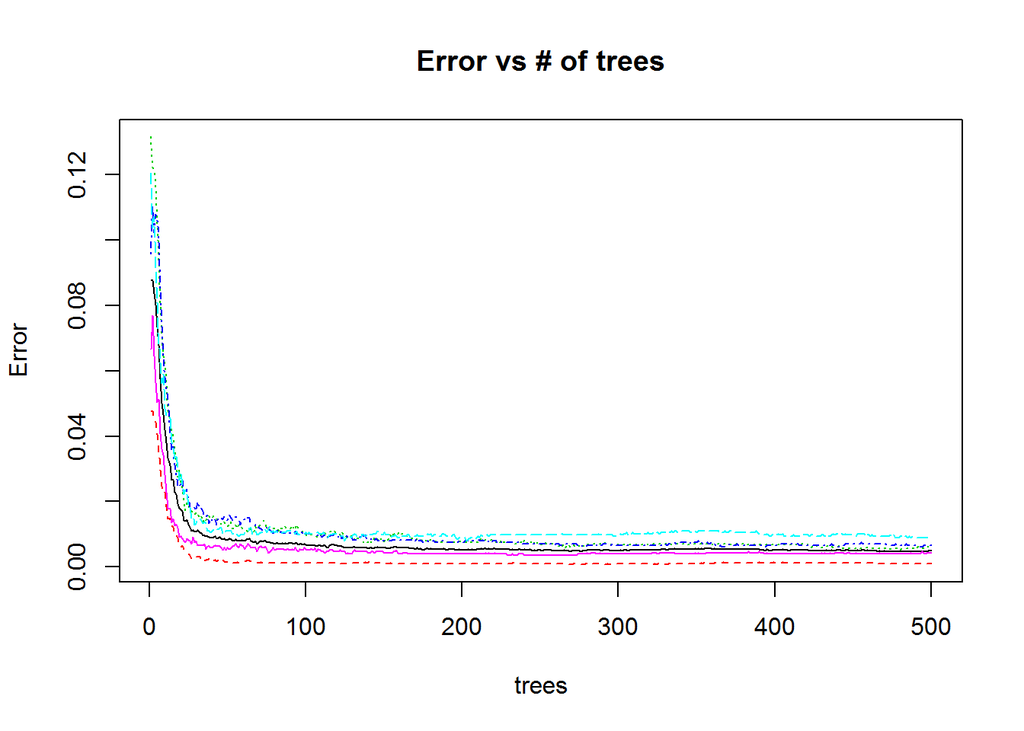

```r
plot(fitFullRF, main="Error vs # of trees")
```

```r
fullCM$overall[1] - pcaCM$overall[1]
```

```
##   Accuracy
## 0.01903144
```

### Finally, run Random Forest method on the actual test dataset

```r
finalRF <- randomForest(training$classe ~., data = training, importance = TRUE)
Answer <- predict(finalRF, testing)
```